# Causal Impact - BMW/VOW

Hugo César Octavio del Sueldo

12/7/2020

## Objetivo

En octubre de 2016 Volkswagen pactó con las autoridades de Estados Unidos pagar 17 500 millones de USD como compensación a los propietarios de los vehículos afectados y a los concesionarios. En Estados Unidos deberá pagar al Departamento de Justicia una multa de 4300 millones de USD (4100 millones de euros)

```r
#periodo inicial
start = "2014-01-01"
treatment = "2015-09-01"
end = "2020-11-01"

#definimos pre y post periodo
pre.period = as.Date(c(start, treatment))
post.period = as.Date(c(treatment, end))
```

```r
#Cargamos ahora los datos de BMW y de Volkswagen
Volkswagen = get.hist.quote(instrument = 'VOW.DE',
                            start = start,
                            end = end,
                            quote = 'Adj',
                            compression = 'w')
```

[output not shown]

```
## time series ends   2020-10-28
```

```r
BMW = get.hist.quote(instrument = 'BMW.DE',
                            start = start,
                            end = end,
                            quote = 'Adj',
                            compression = 'w')
```

```
## time series ends   2020-10-28
```

```r
BMW=na.omit(BMW)
Volkswagen=na.omit(Volkswagen)
```

```r
#Ahora combinamos nuestras acciones juntas

stocks <- cbind(Volkswagen, BMW)
stocks_alreves <- cbind(BMW, Volkswagen)
```

## Causal Impact Volkswagen

```r
# ahora utilizamos CausalImpact para observar

impact <- CausalImpact(data = stocks,
                       pre.period = pre.period,
                       post.period = post.period)
#chequeamos los resultados
summary(impact)
```

```
## Posterior inference {CausalImpact}
##
##                          Average        Cumulative
## Actual                   136            36748
## Prediction (s.d.)        158 (2.7)      42679 (734.2)
## 95% CI                   [153, 163]     [41209, 44110]
##
## Absolute effect (s.d.)   -22 (2.7)      -5931 (734.2)
## 95% CI                   [-27, -17]     [-7361, -4460]
##
## Relative effect (s.d.)   -14% (1.7%)    -14% (1.7%)
## 95% CI                   [-17%, -10%]   [-17%, -10%]
##
## Posterior tail-area probability p:   0.00103
## Posterior prob. of a causal effect:  99.89691%
##
## For more details, type: summary(impact, "report")
```

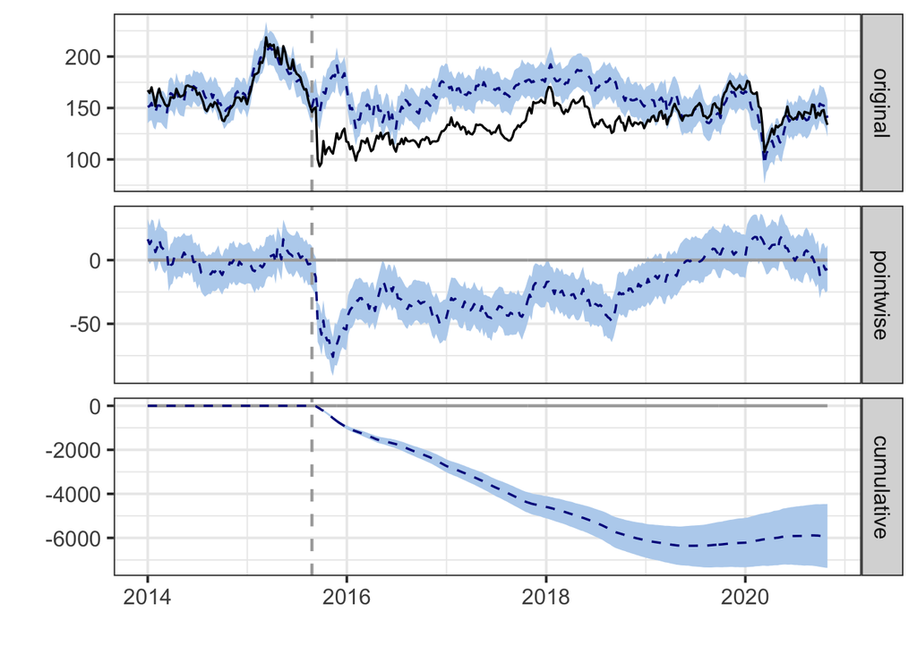

```r
plot(impact)
```

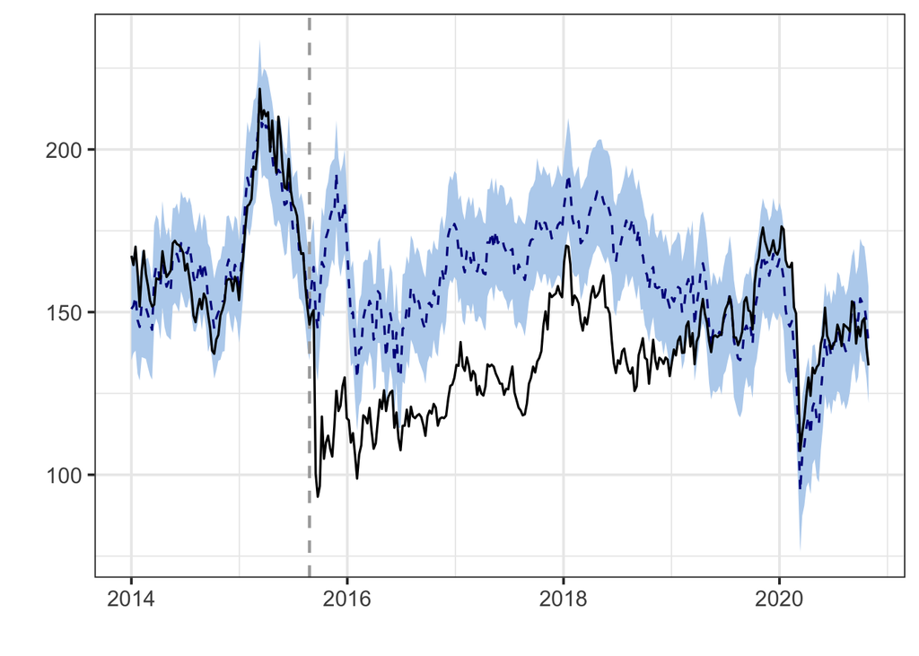

```r
plot(impact, "original")
```

Aqui podemos observar en el grafico acumulado como luego del escandalo sucedido la tendencia de los precios de de Volkswagen fue a la baja desde ese periodo. Al mismo tiempo, en el summary podemos visualizar en los efectos relativos que la accion de Volkswagen perdio un 14% desde ese momento hasta el final de periodo que estamos analizando. Esto incluso fue mucho mayor si observamos la grafica en los periodos hasta 2016 y 2017

```r
summary(impact, "report")
```

```
## Analysis report {CausalImpact}
##
##
## During the post-intervention period, the response variable had an average value of approx. 136.11. By contrast, in the absence of an intervention, we would have expected an average response of 158.07. The 95% interval of this counterfactual prediction is [152.63, 163.37]. Subtracting this predict…
##
## Summing up the individual data points during the post-intervention period (which can only sometimes be meaningfully interpreted), the response variable had an overall value of 36.75K. By contrast, had the intervention not taken place, we would have expected a sum of 42.68K. The 95% interval of th…
##
## The above results are given in terms of absolute numbers. In relative terms, the response variable showed a decrease of -14%. The 95% interval of this percentage is [-17%, -10%].
##
## This means that the negative effect observed during the intervention period is statistically significant. If the experimenter had expected a positive effect, it is recommended to double-check whether anomalies in the control variables may have caused an overly optimistic expectation of what shoul…
##
## The probability of obtaining this effect by chance is very small (Bayesian one-sided tail-area probability p = 0.001). This means the causal effect can be considered statistically significant.
```

## CausalImpact BMW

```r
impact_BMW <- CausalImpact(data = stocks_alreves,
                       pre.period = pre.period,
                       post.period = post.period)
#chequeamos los resultados
summary(impact_BMW)
```

```
## Posterior inference {CausalImpact}
##
##                          Average       Cumulative
## Actual                   67            17978
## Prediction (s.d.)        60 (1.4)      16158 (377.5)
## 95% CI                   [57, 63]      [15380, 16900]
##
## Absolute effect (s.d.)   6.7 (1.4)     1820.6 (377.5)
## 95% CI                   [4, 9.6]      [1078, 2598.3]
##
## Relative effect (s.d.)   11% (2.3%)    11% (2.3%)
## 95% CI                   [6.7%, 16%]   [6.7%, 16%]
##
## Posterior tail-area probability p:   0.00103
## Posterior prob. of a causal effect:  99.89691%
##
## For more details, type: summary(impact, "report")
```

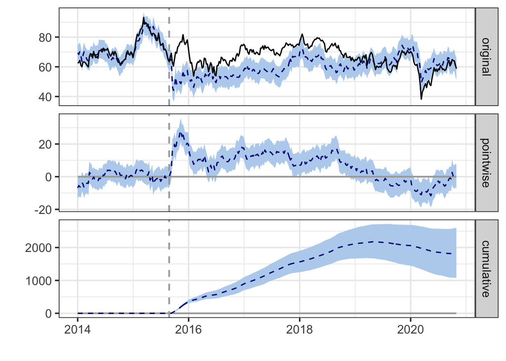

```r
plot(impact_BMW)
```

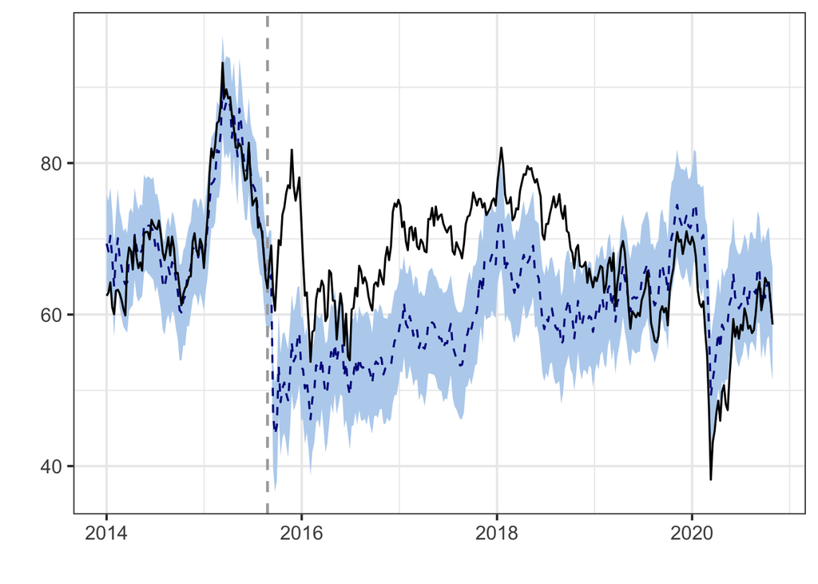

```r
plot(impact_BMW, "original")
```

Aqui podemos observar en el grafico acumulado como luego del escandalo sucedido la tendencia de los precios de BMW fue al alza desde ese periodo. Al mismo tiempo, en el summary podemos visualizar en los efectos relativos que la accion de BMW crecio un 11% desde ese momento hasta el final de periodo que estamos analizando. En este caso particular estamos analizando un periodo largo desde lo sucedido en ese momento, pero, si observamos la serie en los periodos de 2016 y 2017 el alza a causa del diesel gate fue mucho mayor.

```r
summary(impact_BMW, "report")
```

```
## Analysis report {CausalImpact}
##
##
## During the post-intervention period, the response variable had an average value of approx. 66.59. By contrast, in the absence of an intervention, we would have expected an average response of 59.84. The 95% interval of this counterfactual prediction is [56.96, 62.59]. Subtracting this prediction …
##
## Summing up the individual data points during the post-intervention period (which can only sometimes be meaningfully interpreted), the response variable had an overall value of 17.98K. By contrast, had the intervention not taken place, we would have expected a sum of 16.16K. The 95% interval of th…
##
## The above results are given in terms of absolute numbers. In relative terms, the response variable showed an increase of +11%. The 95% interval of this percentage is [+7%, +16%].
##
## This means that the positive effect observed during the intervention period is statistically significant and unlikely to be due to random fluctuations. It should be noted, however, that the question of whether this increase also bears substantive significance can only be answered by comparing the…
##
## The probability of obtaining this effect by chance is very small (Bayesian one-sided tail-area probability p = 0.001). This means the causal effect can be considered statistically significant.
```